# PA1_template

Biel Garcies

1/24/2021

## Loading and preprocessing data

```r
library(readr)
activity <- read_csv("Downloads/activity.csv") #To load data
```

## What is mean total number of steps taken per day?

1. Calculate the total number of steps taken per day

```r
total_steps_by_day<-tapply(activity$steps, activity$date, sum)
```

2. If you do not understand the difference between a histogram and a barplot, research the difference between them. Make a histogram of the total number of steps taken each day

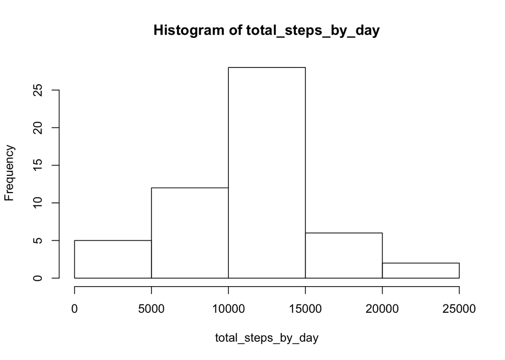

```r
histogram_steps_by_day<-hist(total_steps_by_day)
```

```r
histogram_steps_by_day
```

```
## $breaks
## [1]     0  5000 10000 15000 20000 25000
##
## $counts
## [1]  5 12 28  6  2
##
## $density
## [1] 1.886792e-05 4.528302e-05 1.056604e-04 2.264151e-05 7.547170e-06
##
## $mids
## [1]  2500  7500 12500 17500 22500
##
## $xname
## [1] "total_steps_by_day"
##
## $equidist
## [1] TRUE
##
## attr(,"class")
## [1] "histogram"
```

3. Calculate and report the mean and median of the total number of steps taken per day We start with the mean

```r
mean_steps_by_day<-mean(total_steps_by_day,na.rm = TRUE)
mean_steps_by_day
```

```
## [1] 10766.19
```

And now we calculate the median

```r
median_steps_by_day<-median(total_steps_by_day, na.rm=TRUE)
median_steps_by_day
```

```
## [1] 10765
```

## What is the average daily activity pattern?

1. Make a time series plot (i.e. type = “l”) of the 5-minute interval (x-axis) and the average number of steps taken, averaged across all days (y-axis)

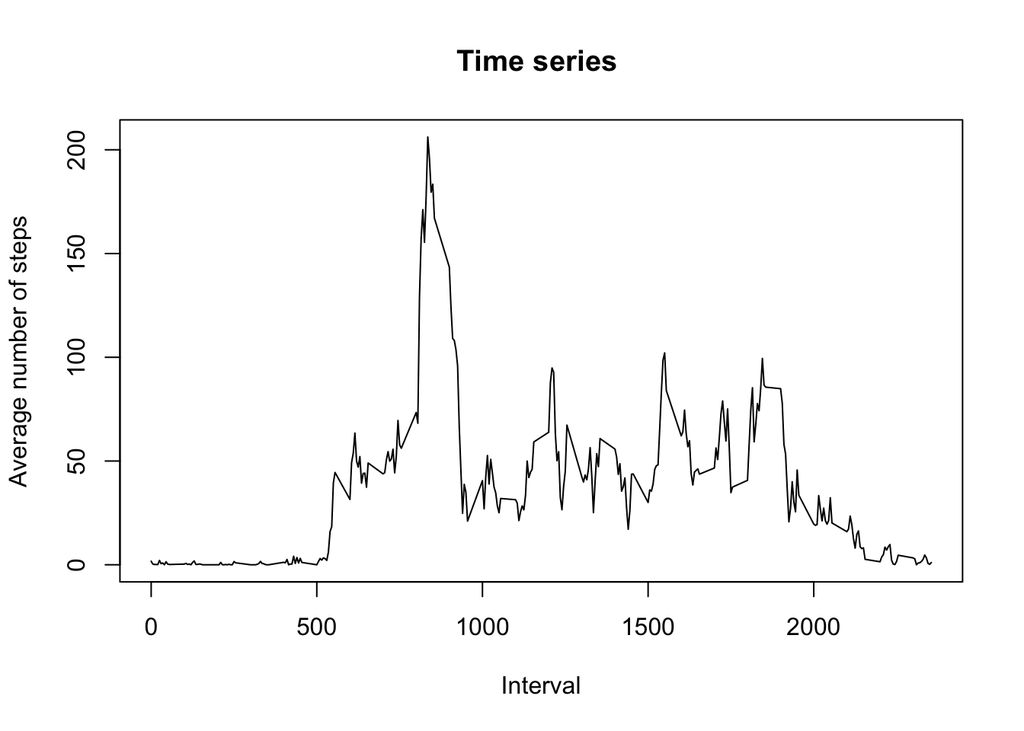

```r
#We group the average number of steps by interval
steps_by_interval<- aggregate(steps~interval, activity, mean)

#We Make the plot
plot(steps_by_interval$interval, steps_by_interval$steps, type = "l", ylab="Average number of steps", xlab= "Interval", main = "Time series ")
```

2. Which 5-minute interval, on average across all the days in the dataset, contains the maximum number of steps?

```r
maximum_interval<-steps_by_interval$interval[which.max(steps_by_interval$steps)]
maximum_interval
```

```
## [1] 835
```

## Imputing missing values

1. Calculate and report the total number of missing values in the dataset (i.e. the total number of rows with NAs)

```r
total_na<-sum(is.na(activity))
total_na
```

```
## [1] 2304
```

2. Devise a strategy for filling in all of the missing values in the dataset. The strategy does not need to be sophisticated. For example, you could use the mean/median for that day, or the mean for that 5-minute interval, etc.

Although there are more exactly ways to replace missing values, we will replace them by the mean for that 5-minute interval

3. Create a new dataset that is equal to the original dataset but with the missing data filled in. We will use a loop to do this.

```r
data_imputed <- activity
for (i in 1:nrow(data_imputed)) {
  if (is.na(data_imputed$steps[i])) {
    interval_value <- data_imputed$interval[i]
    steps_value <- steps_by_interval[steps_by_interval$interval == interval_value,]
    data_imputed$steps[i] <- steps_value$steps}}
```

To check if it has worked:

```r
sum(is.na(data_imputed))
```

```
## [1] 0
```

The loop is correct!

4. Make a histogram of the total number of steps taken each day and Calculate and report the mean and median total number of steps taken per day. Do these values differ from the estimates from the first part of the assignment? What is the impact of imputing missing data on the estimates of the total daily number of steps? We start with the histogram:

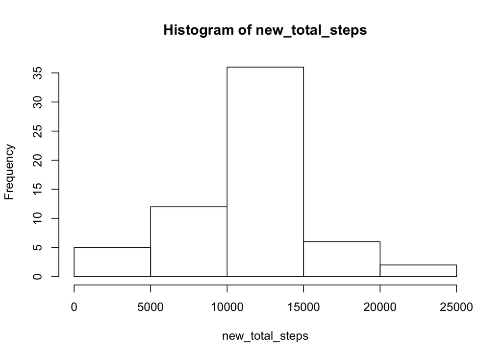

```r
#Calculate the total steps
new_total_steps<-tapply(data_imputed$steps, data_imputed$date, sum)
hist(new_total_steps)
```

Now we calculate the mean

```r
new_steps_mean<-mean(new_total_steps)
new_steps_mean
```

```
## [1] 10766.19
```

It’s the same number!

But when we calculate the new median

```r
new_steps_median<-median(new_total_steps)
new_steps_median
```

```
## [1] 10766.19
```

It’s different!

## Are there differences in activity patterns between weekdays and weekends?

1. Create a new factor variable in the dataset with two levels – “weekday” and “weekend” indicating whether a given date is a weekday or weekend day.

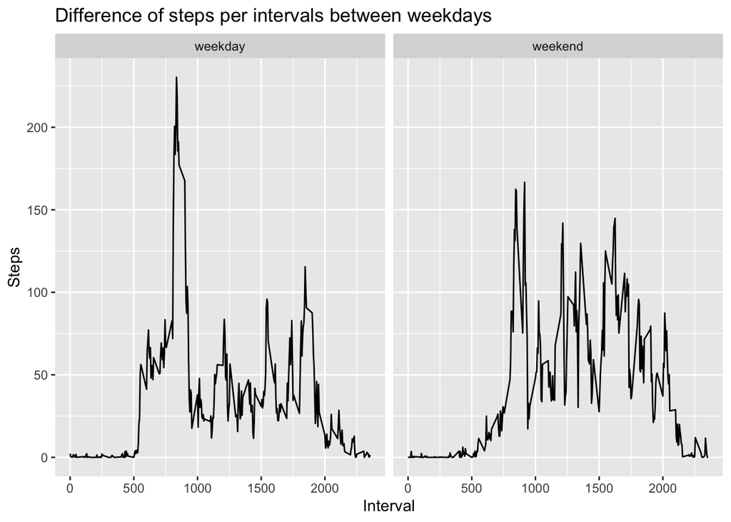

```r
#We create the new variable.
data_imputed$type_of_day <- weekdays(as.Date(data_imputed$date))
data_imputed$type_of_day[data_imputed$type_of_day %in% c("dissabte", "diumenge")] <- "weekend" #"dissabte" and "diumenge" is Saturday and Sunday in Catalan
data_imputed$type_of_day[data_imputed$type_of_day != "weekend"]<-"weekday"

#Aggregate to do the plot
new_steps_by_interval<-aggregate(steps ~interval+ type_of_day, data_imputed, mean)

#Load ggplot2
library(ggplot2)

#Make the plot
qplot(data=new_steps_by_interval, interval, steps, geom="line", xlab="Interval", ylab="Steps", main= "Difference of steps per intervals between weekdays", facets = .~type_of_day)
```